# Part I - Exploring Prosper Loan Data

## by Godswill Sedem Buabassah

[figure not shown]

## Introduction

> Prosper Loans is the first peer-to-peer lending marketplace in the US that has facilitated over 23 billion USD in loans to more than 1.4 million borrowers since its founding in 2005. It offers borrowers fixed-rate, fixed-term loans between USD 2,000 and USD 50,000, while investors can invest in the loans and earn attractive returns. Prosper manages all loan servicing for borrowers and investors. The platform is supported by prominent investors, including Sequoia Capital, Francisco Partners, Institutional Venture Partners, and Credit Suisse NEXT Fund.

> In order to understand why borrowers seek for loans in the first place and to pinpoint a number of potential influencing factors, this research will examine a sample of Prosper loan data. This data set contains 113,937 loans with 81 variables on each loan, including loan amount, borrower rate (or interest rate), current loan status, borrower income, and many others. The variables in the data set are explained in the data dictionary below.

### Data Dictionary

| Variable | Description |
| --- | --- |
| ListingKey | Unique key for each listing, same value as the 'key' used in the listing object in the API. |
| ListingNumber | The number that uniquely identifies the listing to the public as displayed on the website. |
| ListingCreationDate | The date the listing was created. |
| CreditGrade | The Credit rating that was assigned at the time the listing went live. Applicable for listings pre-2009 period and will only be populated for those listings. |
| Term | The length of the loan expressed in months. |
| LoanStatus | The current status of the loan: Cancelled, Chargedoff, Completed, Current, Defaulted, FinalPaymentInProgress, PastDue. The PastDue status will be accompanied by a delinquency bucket. |
| ClosedDate | Closed date is applicable for Cancelled, Completed, Chargedoff and Defaulted loan statuses. |
| BorrowerAPR | The Borrower's Annual Percentage Rate (APR) for the loan. |
| BorrowerRate | The Borrower's interest rate for this loan. |
| LenderYield | The Lender yield on the loan. Lender yield is equal to the interest rate on the loan less the servicing fee. |
| EstimatedEffectiveYield | Effective yield is equal to the borrower interest rate (i) minus the servicing fee rate, (ii) minus estimated uncollected interest on charge-offs, (iii) plus estimated collected late fees. Applicable … |
| EstimatedLoss | Estimated loss is the estimated principal loss on charge-offs. Applicable for loans originated after July 2009. |
| EstimatedReturn | The estimated return assigned to the listing at the time it was created. Estimated return is the difference between the Estimated Effective Yield and the Estimated Loss Rate. Applicable for loans orig… |
| ProsperRating (numeric) | The Prosper Rating assigned at the time the listing was created: 0 - N/A, 1 - HR, 2 - E, 3 - D, 4 - C, 5 - B, 6 - A, 7 - AA. Applicable for loans originated after July 2009. |
| ProsperRating (Alpha) | The Prosper Rating assigned at the time the listing was created between AA - HR. Applicable for loans originated after July 2009. |
| ProsperScore | A custom risk score built using historical Prosper data. The score ranges from 1-10, with 10 being the best, or lowest risk score. Applicable for loans originated after July 2009 |
| ListingCategory | The category of the listing that the borrower selected when posting their listing: 0 - Not Available, 1 - Debt Consolidation, 2 - Home Improvement, 3 - Business, 4 - Personal Loan, 5 - Student Use, 6 … |
| BorrowerState | The two letter abbreviation of the state of the address of the borrower at the time the Listing was created. |
| Occupation | The Occupation selected by the Borrower at the time they created the listing. |
| EmploymentStatus | The employment status of the borrower at the time they posted the listing. |
| EmploymentStatusDuration | The length in months of the employment status at the time the listing was created. |
| IsBorrowerHomeowner | A Borrower will be classified as a homowner if they have a mortgage on their credit profile or provide documentation confirming they are a homeowner. |
| CurrentlyInGroup | Specifies whether or not the Borrower was in a group at the time the listing was created. |
| GroupKey | The Key of the group in which the Borrower is a member of. Value will be null if the borrower does not have a group affiliation. |
| DateCreditPulled | The date the credit profile was pulled. |
| CreditScoreRangeLower | The lower value representing the range of the borrower's credit score as provided by a consumer credit rating agency. |
| CreditScoreRangeUpper | The upper value representing the range of the borrower's credit score as provided by a consumer credit rating agency. |
| FirstRecordedCreditLine | The date the first credit line was opened. |
| CurrentCreditLines | Number of current credit lines at the time the credit profile was pulled. |
| OpenCreditLines | Number of open credit lines at the time the credit profile was pulled. |

[output cut: 51 more lines]

> **Rubric Tip**: Your code should not generate any errors, and should use functions, loops where possible to reduce repetitive code. Prefer to use functions to reuse code statements.

> **Rubric Tip**: Document your approach and findings in markdown cells. Use comments and docstrings in code cells to document the code functionality.

> **Rubric Tip**: Markup cells should have headers and text that organize your thoughts, findings, and what you plan on investigating next.

## Preliminary Wrangling

```python
# import all packages and set plots to be embedded inline
import numpy as np
import pandas as pd
import matplotlib.pyplot as plt
import seaborn as sb

%matplotlib inline
import warnings
warnings.filterwarnings("ignore")
```

> Load in your dataset and describe its properties through the questions below. Try and motivate your exploration goals through this section.

```python
# Load the Prosper loan data
df = pd.read_csv('prosperLoanData.csv')
```

```python
# Check the sape of the dataset
print(f'The Prosper loan data has\n{df.shape[1]} columns and\n{df.shape[0]} rows')
```

```
The Prosper loan data has
81 columns and
113937 rows
```

### Assessing Data

A thorough visual assessement was done in excel and the programatic assesement is presented below

```python
# View 30 random observations
df.sample(30)
```

|  | ListingKey | ListingNumber | ListingCreationDate | CreditGrade | Term | LoanStatus | ClosedDate | BorrowerAPR | BorrowerRate | LenderYield | ... | LP_ServiceFees | LP_CollectionFees | LP_GrossPrincipalLoss | LP_NetPrincipalLoss | LP_NonPrincipalRecoverypayments | PercentFunded | Recommendations | InvestmentFromFriendsCount | InvestmentFromFriendsAmount | Investors |
| --- | --- | --- | --- | --- | --- | --- | --- | --- | --- | --- | --- | --- | --- | --- | --- | --- | --- | --- | --- | --- | --- |
| 44301 | 16BE3543079595304F4E005 | 569525 | 2012-03-18 06:18:38.973000000 | NaN | 60 | Current | NaN | 0.31375 | 0.2870 | 0.2770 | ... | -74.05 | 0.00 | 0.00 | 0.00 | 0.0 | 1.0 | 0 | 0 | 0.0 | 53 |
| 109078 | 22A83551040041012149368 | 606218 | 2012-06-30 11:33:17.650000000 | NaN | 36 | Current | NaN | 0.28851 | 0.2499 | 0.2399 | ... | -192.62 | 0.00 | 0.00 | 0.00 | 0.0 | 1.0 | 0 | 0 | 0.0 | 22 |
| 92255 | 76DF3413651618340B29BE2 | 284824 | 2008-02-26 17:38:20.700000000 | A | 36 | Completed | 2010-02-19 00:00:00 | 0.12201 | 0.1080 | 0.0980 | ... | -42.18 | 0.00 | 0.00 | 0.00 | 0.0 | 1.0 | 0 | 0 | 0.0 | 91 |
| 111079 | 80E534661342036891C0D98 | 430401 | 2009-10-26 16:54:35.037000000 | NaN | 36 | Completed | 2012-11-09 00:00:00 | 0.36712 | 0.3427 | 0.3327 | ... | -89.71 | 0.00 | 0.00 | 0.00 | 0.0 | 1.0 | 0 | 0 | 0.0 | 64 |
| 82523 | C7993598628026326CC4CA6 | 1100253 | 2013-12-20 09:32:44.427000000 | NaN | 36 | Completed | 2014-02-04 00:00:00 | 0.17611 | 0.1400 | 0.1300 | ... | -4.16 | 0.00 | 0.00 | 0.00 | 0.0 | 1.0 | 0 | 0 | 0.0 | 1 |
| 113064 | EAAA355764212007892BE79 | 637309 | 2012-09-10 08:49:45.957000000 | NaN | 60 | Completed | 2013-03-19 00:00:00 | 0.15936 | 0.1364 | 0.1264 | ... | -116.46 | 0.00 | 0.00 | 0.00 | 0.0 | 1.0 | 0 | 0 | 0.0 | 246 |
| 60197 | AB4F3569393536904D7E6AB | 709477 | 2013-02-05 12:20:31.127000000 | NaN | 36 | Past Due (1-15 days) | NaN | 0.30285 | 0.2639 | 0.2539 | ... | -37.18 | -55.08 | 0.00 | 0.00 | 0.0 | 1.0 | 0 | 0 | 0.0 | 20 |
| 7464 | 09323600455981215BE1CD3 | 1163306 | 2014-01-25 15:45:02.560000000 | NaN | 36 | Current | NaN | 0.17151 | 0.1355 | 0.1255 | ... | 0.00 | 0.00 | 0.00 | 0.00 | 0.0 | 1.0 | 0 | 0 | 0.0 | 141 |
| 10948 | 5CB1358581344350507DF34 | 870688 | 2013-08-15 06:56:16.797000000 | NaN | 60 | Current | NaN | 0.13227 | 0.1099 | 0.0999 | ... | -93.25 | 0.00 | 0.00 | 0.00 | 0.0 | 1.0 | 0 | 0 | 0.0 | 295 |
| 71391 | C95033800399760385DE076 | 92380 | 2007-02-02 09:52:52.310000000 | AA | 36 | Completed | 2007-11-06 00:00:00 | 0.07349 | 0.0650 | 0.0600 | ... | -3.86 | 0.00 | 0.00 | 0.00 | 0.0 | 1.0 | 0 | 0 | 0.0 | 32 |
| 83986 | 432335103862727528B97A2 | 496856 | 2011-03-06 06:38:25.547000000 | NaN | 36 | Completed | 2012-03-18 00:00:00 | 0.29510 | 0.2599 | 0.2499 | ... | -109.15 | 0.00 | 0.00 | 0.00 | 0.0 | 1.0 | 0 | 0 | 0.0 | 247 |
| 84173 | EA55339670939088879CCF2 | 178557 | 2007-07-30 09:52:54.510000000 | E | 36 | Chargedoff | 2008-12-07 00:00:00 | 0.19987 | 0.1852 | 0.1652 | ... | -14.71 | 0.00 | 1351.57 | 1351.57 | 0.0 | 1.0 | 0 | 0 | 0.0 | 8 |
| 47567 | 32FE3377212779035783C66 | 76432 | 2006-12-19 16:45:35.347000000 | D | 36 | Completed | 2008-08-26 00:00:00 | 0.15713 | 0.1500 | 0.1400 | ... | -31.69 | 0.00 | 0.00 | 0.00 | 0.0 | 1.0 | 0 | 0 | 0.0 | 138 |
| 43951 | 30823375652614973B988C3 | 74667 | 2006-12-14 12:32:01.697000000 | AA | 36 | Completed | 2008-05-26 00:00:00 | 0.08516 | 0.0680 | 0.0630 | ... | -4.38 | 0.00 | 0.00 | 0.00 | 0.0 | 1.0 | 0 | 0 | 0.0 | 30 |
| 88720 | 55593536016811411BD1DB9 | 548006 | 2012-01-01 07:35:10.960000000 | NaN | 12 | Completed | 2012-10-16 00:00:00 | 0.17688 | 0.1000 | 0.0900 | ... | -20.38 | 0.00 | 0.00 | 0.00 | 0.0 | 1.0 | 0 | 0 | 0.0 | 72 |
| 68620 | 742A35240652265497F7A9F | 520926 | 2011-08-09 13:43:18.627000000 | NaN | 36 | Current | NaN | 0.30532 | 0.2699 | 0.2599 | ... | -49.53 | 0.00 | 0.00 | 0.00 | 0.0 | 1.0 | 0 | 0 | 0.0 | 65 |
| 101662 | 28593544492130006858973 | 582645 | 2012-04-25 22:36:49.550000000 | NaN | 36 | Completed | 2013-04-04 00:00:00 | 0.35797 | 0.3177 | 0.3077 | ... | -16.85 | 0.00 | 0.00 | 0.00 | 0.0 | 1.0 | 0 | 0 | 0.0 | 21 |
| 15286 | 9CBD3462397300118951F04 | 423887 | 2009-09-10 15:01:06.940000000 | NaN | 36 | Completed | 2012-10-01 00:00:00 | 0.18882 | 0.1669 | 0.1569 | ... | -29.99 | 0.00 | 0.00 | 0.00 | 0.0 | 1.0 | 0 | 0 | 0.0 | 135 |
| 63017 | 202435996586892186CF86E | 1080130 | 2014-01-03 12:19:01.537000000 | NaN | 36 | Current | NaN | 0.18006 | 0.1435 | 0.1335 | ... | 0.00 | 0.00 | 0.00 | 0.00 | 0.0 | 1.0 | 0 | 0 | 0.0 | 1 |
| 79597 | A57034194938664808FFB36 | 328788 | 2008-05-08 12:16:06.137000000 | NaN | 36 | Completed | 2010-02-05 00:00:00 | 0.20210 | 0.1800 | 0.1700 | ... | -9.41 | 0.00 | 0.00 | 0.00 | 0.0 | 1.0 | 0 | 0 | 0.0 | 167 |
| 91845 | B277360043601911940D837 | 1172069 | 2014-01-28 13:15:37.007000000 | NaN | 36 | Current | NaN | 0.17969 | 0.1435 | 0.1335 | ... | 0.00 | 0.00 | 0.00 | 0.00 | 0.0 | 1.0 | 0 | 0 | 0.0 | 3 |
| 94590 | C3D53423762761163813EEC | 350656 | 2008-06-14 19:34:26.653000000 | E | 36 | Completed | 2011-05-23 00:00:00 | 0.37453 | 0.3500 | 0.3400 | ... | -18.74 | 0.00 | 0.00 | 0.00 | 0.0 | 1.0 | 0 | 0 | 0.0 | 13 |
| 7288 | 69603377091912333DF57EA | 76267 | 2006-12-19 08:08:30.523000000 | HR | 36 | Chargedoff | 2008-09-20 00:00:00 | 0.30300 | 0.2900 | 0.2850 | ... | -8.65 | 0.00 | 995.58 | 995.55 | 0.0 | 1.0 | 0 | 0 | 0.0 | 22 |
| 73590 | 93593459707321856D860C8 | 420183 | 2009-08-11 18:08:23.903000000 | NaN | 36 | Completed | 2012-08-28 00:00:00 | 0.18807 | 0.1637 | 0.1537 | ... | -23.83 | 0.00 | 0.00 | 0.00 | 0.0 | 1.0 | 0 | 0 | 0.0 | 82 |
| 102815 | 8E9C3584295035248CD3EDB | 838073 | 2013-07-13 15:52:47.593000000 | NaN | 36 | Current | NaN | 0.35356 | 0.3134 | 0.3034 | ... | -22.32 | 0.00 | 0.00 | 0.00 | 0.0 | 1.0 | 0 | 0 | 0.0 | 1 |
| 36820 | EF6D348967202988650C1FC | 469283 | 2010-07-30 08:41:13.220000000 | NaN | 36 | Completed | 2013-08-13 00:00:00 | 0.28498 | 0.2500 | 0.2400 | ... | -43.22 | 0.00 | 0.00 | 0.00 | 0.0 | 1.0 | 0 | 0 | 0.0 | 118 |
| 11389 | A0493580748100605D07763 | 813846 | 2013-06-18 14:55:27.310000000 | NaN | 36 | Current | NaN | 0.21025 | 0.1734 | 0.1634 | ... | -30.97 | 0.00 | 0.00 | 0.00 | 0.0 | 1.0 | 0 | 0 | 0.0 | 50 |
| 111026 | 7AC3357619613481082CFC9 | 749732 | 2013-04-11 11:24:02.487000000 | NaN | 60 | Current | NaN | 0.25359 | 0.2284 | 0.2184 | ... | -120.38 | 0.00 | 0.00 | 0.00 | 0.0 | 1.0 | 0 | 0 | 0.0 | 1 |
| 98020 | A4033580770429258F96358 | 806839 | 2013-06-12 14:16:52.143000000 | NaN | 60 | Current | NaN | 0.23872 | 0.2139 | 0.2039 | ... | -50.68 | 0.00 | 0.00 | 0.00 | 0.0 | 1.0 | 0 | 0 | 0.0 | 1 |
| 99745 | 2545337521935099053BC3F | 71961 | 2006-12-07 22:04:34.260000000 | HR | 36 | Defaulted | 2007-11-19 00:00:00 | 0.25757 | 0.2500 | 0.2250 | ... | -7.22 | 0.00 | 2677.04 | 2677.03 | 0.0 | 1.0 | 0 | 0 | 0.0 | 77 |

30 rows × 81 columns

```python
# Obtain summarry information about the dataset
df.info()
```

```
<class 'pandas.core.frame.DataFrame'>
RangeIndex: 113937 entries, 0 to 113936
Data columns (total 81 columns):
 #   Column                               Non-Null Count   Dtype
---  ------                               --------------   -----
 0   ListingKey                           113937 non-null  object
 1   ListingNumber                        113937 non-null  int64
 2   ListingCreationDate                  113937 non-null  object
 3   CreditGrade                          28953 non-null   object
 4   Term                                 113937 non-null  int64
 5   LoanStatus                           113937 non-null  object
 6   ClosedDate                           55089 non-null   object
 7   BorrowerAPR                          113912 non-null  float64
 8   BorrowerRate                         113937 non-null  float64
 9   LenderYield                          113937 non-null  float64
```

[output cut: 73 more lines]

Based on the above output, some columns have a high signicant amount of missing values.

```python
# Check the descriptive statistics
df.describe().round(2).T
```

|  | count | mean | std | min | 25% | 50% | 75% | max |
| --- | --- | --- | --- | --- | --- | --- | --- | --- |
| ListingNumber | 113937.0 | 627885.69 | 328076.24 | 4.00 | 400919.00 | 600554.00 | 892634.00 | 1255725.00 |
| Term | 113937.0 | 40.83 | 10.44 | 12.00 | 36.00 | 36.00 | 36.00 | 60.00 |
| BorrowerAPR | 113912.0 | 0.22 | 0.08 | 0.01 | 0.16 | 0.21 | 0.28 | 0.51 |
| BorrowerRate | 113937.0 | 0.19 | 0.07 | 0.00 | 0.13 | 0.18 | 0.25 | 0.50 |
| LenderYield | 113937.0 | 0.18 | 0.07 | -0.01 | 0.12 | 0.17 | 0.24 | 0.49 |
| ... | ... | ... | ... | ... | ... | ... | ... | ... |
| PercentFunded | 113937.0 | 1.00 | 0.02 | 0.70 | 1.00 | 1.00 | 1.00 | 1.01 |
| Recommendations | 113937.0 | 0.05 | 0.33 | 0.00 | 0.00 | 0.00 | 0.00 | 39.00 |
| InvestmentFromFriendsCount | 113937.0 | 0.02 | 0.23 | 0.00 | 0.00 | 0.00 | 0.00 | 33.00 |
| InvestmentFromFriendsAmount | 113937.0 | 16.55 | 294.55 | 0.00 | 0.00 | 0.00 | 0.00 | 25000.00 |
| Investors | 113937.0 | 80.48 | 103.24 | 1.00 | 2.00 | 44.00 | 115.00 | 1189.00 |

61 rows × 8 columns

```python
# Check for duplicate rows
duplicates = df.duplicated().sum()
print(f'There are {duplicates} duplicate records in the dataset.')
```

```
There are 0 duplicate records in the dataset.
```

```python
# Check the unique values and number of unique values of all columns having object dtype
for column in df.columns:
    if df[column].nunique() < 100:
        print(column, df[column].nunique())
        print("<=======================>")
        print(df[column].unique())
        print("====================================================================================")
    else:
        pass
```

```
CreditGrade 8
<=======================>
['C' nan 'HR' 'AA' 'D' 'B' 'E' 'A' 'NC']
====================================================================================
Term 3
<=======================>
[36 60 12]
====================================================================================
LoanStatus 12
<=======================>
['Completed' 'Current' 'Past Due (1-15 days)' 'Defaulted' 'Chargedoff'
 'Past Due (16-30 days)' 'Cancelled' 'Past Due (61-90 days)'
 'Past Due (31-60 days)' 'Past Due (91-120 days)' 'FinalPaymentInProgress'
 'Past Due (>120 days)']
====================================================================================
ProsperRating (numeric) 7
<=======================>
[nan  6.  3.  5.  2.  4.  7.  1.]
====================================================================================
ProsperRating (Alpha) 7
<=======================>
[nan 'A' 'D' 'B' 'E' 'C' 'AA' 'HR']
====================================================================================
ProsperScore 11
<=======================>
[nan  7.  9.  4. 10.  2. 11.  8.  5.  3.  6.  1.]
====================================================================================
ListingCategory (numeric) 21
<=======================>
[ 0  2 16  1  7 13  6 15 20 19  3 18  8  4 11 14  5  9 17 10 12]
====================================================================================
BorrowerState 51
<=======================>
['CO' 'GA' 'MN' 'NM' 'KS' 'CA' 'IL' 'MD' nan 'AL' 'AZ' 'VA' 'FL' 'PA' 'OR'
 'MI' 'NY' 'LA' 'WI' 'OH' 'NC' 'WA' 'NV' 'NJ' 'TX' 'AR' 'SC' 'DE' 'MO'
 'NE' 'UT' 'DC' 'MA' 'CT' 'IN' 'KY' 'OK' 'MS' 'WV' 'RI' 'TN' 'ID' 'MT'
 'HI' 'NH' 'VT' 'WY' 'ME' 'AK' 'IA' 'SD' 'ND']
====================================================================================
Occupation 67
<=======================>
```

[output cut: 137 more lines]

```
<=======================>
['Q3 2007' 'Q1 2014' 'Q1 2007' 'Q4 2012' 'Q3 2013' 'Q4 2013' 'Q2 2013'
 'Q2 2012' 'Q4 2007' 'Q3 2006' 'Q1 2013' 'Q2 2010' 'Q1 2012' 'Q3 2012'
 'Q4 2010' 'Q4 2011' 'Q3 2008' 'Q2 2007' 'Q4 2006' 'Q2 2011' 'Q1 2011'
 'Q1 2008' 'Q3 2009' 'Q3 2011' 'Q2 2008' 'Q1 2010' 'Q4 2009' 'Q2 2006'
 'Q3 2010' 'Q1 2006' 'Q4 2008' 'Q4 2005' 'Q2 2009']
====================================================================================
Recommendations 17
<=======================>
[ 0  2  1  4  3  9  5 16 39 21  7 14  8  6 24 19 18]
====================================================================================
InvestmentFromFriendsCount 14
<=======================>
[ 0  1  2  9  4  3 33 20 15  5  6 13  8  7]
====================================================================================
```

### Data Quality and Tidiness Issues

1. LoanOriginationDate, DateCreditPulled, ClosedDate and ListingCreationDate are of dtype object instead of datetime.
2. Renaming columns; ListingCategory (numeric), ProsperRating (Alpha), ProsperRating (numeric) and TradesNeverDelinquent (percentage)
3. Drop columns with extremely high number (over 50%) of missing values since they present less information.
4. ListingCategory are in numeric. The numeric values have to be changed to reflect meaning of the categories.
5. Separate LoanOriginationQuarter entries into separate columns LoanOriginationQuarter and LoanOriginationYear.
6. Convert the dtype of ListingNumber to string to prevent arithmetic operations from having effect on it.

### Data Cleaning

```python
# Make a copy of original data
df_cleaned = df.copy()
```

#### Issue #1: Change all dates from object dtype to datetime

#### Code

```python
# Create a list of all columns with dates
dates = ['LoanOriginationDate', 'DateCreditPulled', 'ClosedDate', 'ListingCreationDate']

#convert dates to datetime
for date in dates:
    df_cleaned[date] = pd.to_datetime(df_cleaned[date])
```

#### Test

```python
# Check if changes have taken place.
for date in dates:
    assert df_cleaned[date].dtype == 'datetime64[ns]'
```

#### Issue #2: Renaming columns

#### Code

```python
# Rename the columns
new_column_names = {'ListingCategory (numeric)': 'ListingCategory',
                    'ProsperRating (Alpha)': 'ProsperRatingAlpha',
                    'ProsperRating (numeric)':'ProsperRatingNumeric',
                    'TradesNeverDelinquent (percentage)':'TradesNeverDelinquentPercentage'}

df_cleaned = df_cleaned.rename(columns=new_column_names)
```

#### Test

```python
# Confirm changes
column_names = ['ListingCategory','ProsperRatingAlpha','ProsperRatingNumeric','TradesNeverDelinquentPercentage']
assert set(column_names).issubset(df_cleaned.columns)
```

#### Issue #3 Drop columns with extremely high number (over 50%) of missing values since they present less information.

#### Code

```python
# Drop columns with over 50% missing values
threshold = 0.5
df_cleaned = df_cleaned.loc[:, (df_cleaned.isna().sum() / len(df_cleaned)) <= threshold]
```

#### Test

```python
# Check that proportion of missing values is below threshold
assert (df_cleaned.isna().mean() <= threshold).all()
```

#### Issue #4: Converting numeric entries to strings that reflect actual ListingCategory.

#### Code

```python
# Define a dictionary to store all the numeric categories and their corresponding string categories.
listing_categories = {
    0: 'Not Available',
    1: 'Debt Consolidation',
    2: 'Home Improvement',
    3: 'Business',
    4: 'Personal Loan',
    5: 'Student Use',
    6: 'Auto',
    7: 'Other',
    8: 'Baby & Adoption',
    9: 'Boat',
    10: 'Cosmetic Procedure',
    11: 'Engagement Ring',
    12: 'Green Loans',
    13: 'Household Expenses',
    14: 'Large Purchases',
    15: 'Medical or Dental',
    16: 'Motorcycle',
    17: 'RV',
    18: 'Taxes',
    19: 'Vacation',
    20: 'Wedding Loans'
}

# Map the dictionary to the 'ListingCategory' column of the df_cleaned DataFrame
df_cleaned['ListingCategory'] = df_cleaned['ListingCategory'].map(listing_categories)
```

#### Test

```python
# Confirm changes
df_cleaned['ListingCategory'].unique()
```

```
array(['Not Available', 'Home Improvement', 'Motorcycle',
       'Debt Consolidation', 'Other', 'Household Expenses', 'Auto',
       'Medical or Dental', 'Wedding Loans', 'Vacation', 'Business',
       'Taxes', 'Baby & Adoption', 'Personal Loan', 'Engagement Ring',
       'Large Purchases', 'Student Use', 'Boat', 'RV',
       'Cosmetic Procedure', 'Green Loans'], dtype=object)
```

#### Issue #5: Separate LoanOriginationQuarter entries into separate columns, LoanOriginationQuarter and LoanOriginationYear.

#### Code

```python
# Use lambda functions and string manipulation to extract the year and quarter into separate columns
df_cleaned['LoanOriginationYear'] = df_cleaned['LoanOriginationQuarter'].apply(lambda x: x.split()[1])
df_cleaned['LoanOriginationQuarter'] = df_cleaned['LoanOriginationQuarter'].apply(lambda x: x.split()[0])
```

#### Test

```python
# Check if the columns are part fo the dataframe
assert set(['LoanOriginationQuarter','LoanOriginationYear']).issubset(df_cleaned.columns)
```

```python
# Confirm the values
df_cleaned.LoanOriginationQuarter.unique()
```

```
array(['Q3', 'Q1', 'Q4', 'Q2'], dtype=object)
```

```python
# Confirm the values
df_cleaned.LoanOriginationYear.unique()
```

```
array(['2007', '2014', '2012', '2013', '2006', '2010', '2011', '2008',
       '2009', '2005'], dtype=object)
```

#### Issue #6: Convert the dtype of ListingNumber to string

#### Code

```python
# Convert dtype to string
df_cleaned.ListingNumber = df_cleaned.ListingNumber.astype('str')
```

#### Test

```python
# Check if changes have taken place.
assert df_cleaned.ListingNumber.dtype == 'object'
```

#### Issue #7: Drop all rows without 'ProsperRating' and 'ProsperScore'

```python
# Create a list of columns with null values
columns_with_null_values = ['BorrowerAPR', 'ProsperRatingNumeric', 'ProsperRatingAlpha','ProsperScore']

# Subset all rows where 'BorrowerAPR', 'ProsperRating' and 'ProsperScore do not record missing values.
df_cleaned = df_cleaned.dropna(subset=columns_with_null_values)
```

```python
assert df_cleaned.isna().sum().all() == 0
```

```python
df_cleaned.info()
```

```
<class 'pandas.core.frame.DataFrame'>
Int64Index: 84853 entries, 1 to 113936
Data columns (total 70 columns):
 #   Column                           Non-Null Count  Dtype
---  ------                           --------------  -----
 0   ListingKey                       84853 non-null  object
 1   ListingNumber                    84853 non-null  object
 2   ListingCreationDate              84853 non-null  datetime64[ns]
 3   Term                             84853 non-null  int64
 4   LoanStatus                       84853 non-null  object
 5   BorrowerAPR                      84853 non-null  float64
 6   BorrowerRate                     84853 non-null  float64
 7   LenderYield                      84853 non-null  float64
 8   EstimatedEffectiveYield          84853 non-null  float64
 9   EstimatedLoss                    84853 non-null  float64
```

[output cut: 62 more lines]

DebtToIncomeRatio still have missing values and that is probably because at the time of applying for loan the client might not have any debt or might be unemployed.

```python
# Check the descriptive statistics
df_cleaned.describe().round(2).T
```

|  | count | mean | std | min | 25% | 50% | 75% | max |
| --- | --- | --- | --- | --- | --- | --- | --- | --- |
| Term | 84853.0 | 42.49 | 11.64 | 12.00 | 36.00 | 36.00 | 60.00 | 60.00 |
| BorrowerAPR | 84853.0 | 0.23 | 0.08 | 0.05 | 0.16 | 0.22 | 0.29 | 0.42 |
| BorrowerRate | 84853.0 | 0.20 | 0.07 | 0.04 | 0.14 | 0.19 | 0.26 | 0.36 |
| LenderYield | 84853.0 | 0.19 | 0.07 | 0.03 | 0.13 | 0.18 | 0.25 | 0.34 |
| EstimatedEffectiveYield | 84853.0 | 0.17 | 0.07 | -0.18 | 0.12 | 0.16 | 0.22 | 0.32 |
| EstimatedLoss | 84853.0 | 0.08 | 0.05 | 0.00 | 0.04 | 0.07 | 0.11 | 0.37 |
| EstimatedReturn | 84853.0 | 0.10 | 0.03 | -0.18 | 0.07 | 0.09 | 0.12 | 0.28 |
| ProsperRatingNumeric | 84853.0 | 4.07 | 1.67 | 1.00 | 3.00 | 4.00 | 5.00 | 7.00 |
| ProsperScore | 84853.0 | 5.95 | 2.38 | 1.00 | 4.00 | 6.00 | 8.00 | 11.00 |
| EmploymentStatusDuration | 84834.0 | 103.06 | 97.08 | 0.00 | 30.00 | 74.00 | 148.00 | 755.00 |
| CreditScoreRangeLower | 84853.0 | 699.39 | 47.10 | 600.00 | 660.00 | 700.00 | 720.00 | 880.00 |
| CreditScoreRangeUpper | 84853.0 | 718.39 | 47.10 | 619.00 | 679.00 | 719.00 | 739.00 | 899.00 |
| CurrentCreditLines | 84853.0 | 10.51 | 5.32 | 0.00 | 7.00 | 10.00 | 13.00 | 59.00 |
| OpenCreditLines | 84853.0 | 9.53 | 4.93 | 0.00 | 6.00 | 9.00 | 12.00 | 54.00 |
| TotalCreditLinespast7years | 84853.0 | 27.66 | 13.27 | 2.00 | 18.00 | 26.00 | 35.00 | 125.00 |
| OpenRevolvingAccounts | 84853.0 | 7.39 | 4.52 | 0.00 | 4.00 | 7.00 | 10.00 | 50.00 |
| OpenRevolvingMonthlyPayment | 84853.0 | 430.72 | 425.87 | 0.00 | 156.00 | 311.00 | 564.00 | 13765.00 |
| InquiriesLast6Months | 84853.0 | 0.96 | 1.40 | 0.00 | 0.00 | 0.00 | 1.00 | 27.00 |
| TotalInquiries | 84853.0 | 4.29 | 3.83 | 0.00 | 2.00 | 3.00 | 6.00 | 78.00 |
| CurrentDelinquencies | 84853.0 | 0.32 | 1.11 | 0.00 | 0.00 | 0.00 | 0.00 | 51.00 |
| AmountDelinquent | 84853.0 | 950.77 | 7419.57 | 0.00 | 0.00 | 0.00 | 0.00 | 463881.00 |
| DelinquenciesLast7Years | 84853.0 | 3.66 | 9.35 | 0.00 | 0.00 | 0.00 | 2.00 | 99.00 |
| PublicRecordsLast10Years | 84853.0 | 0.29 | 0.65 | 0.00 | 0.00 | 0.00 | 0.00 | 38.00 |
| PublicRecordsLast12Months | 84853.0 | 0.01 | 0.13 | 0.00 | 0.00 | 0.00 | 0.00 | 20.00 |
| RevolvingCreditBalance | 84853.0 | 17940.24 | 31367.47 | 0.00 | 3824.00 | 9323.00 | 20339.00 | 999165.00 |
| BankcardUtilization | 84853.0 | 0.56 | 0.30 | 0.00 | 0.33 | 0.60 | 0.83 | 2.50 |
| AvailableBankcardCredit | 84853.0 | 11400.70 | 18610.42 | 0.00 | 1148.00 | 4574.00 | 13910.00 | 498374.00 |
| TotalTrades | 84853.0 | 23.93 | 11.61 | 1.00 | 16.00 | 23.00 | 31.00 | 122.00 |
| TradesNeverDelinquentPercentage | 84853.0 | 0.91 | 0.12 | 0.08 | 0.85 | 0.95 | 1.00 | 1.00 |
| TradesOpenedLast6Months | 84853.0 | 0.73 | 0.99 | 0.00 | 0.00 | 0.00 | 1.00 | 20.00 |
| DebtToIncomeRatio | 77557.0 | 0.26 | 0.32 | 0.00 | 0.15 | 0.22 | 0.32 | 10.01 |
| StatedMonthlyIncome | 84853.0 | 5931.17 | 8239.94 | 0.00 | 3434.00 | 5000.00 | 7083.33 | 1750002.92 |
| LoanCurrentDaysDelinquent | 84853.0 | 36.63 | 150.42 | 0.00 | 0.00 | 0.00 | 0.00 | 1593.00 |
| LoanMonthsSinceOrigination | 84853.0 | 16.02 | 13.90 | 0.00 | 4.00 | 11.00 | 25.00 | 56.00 |
| LoanNumber | 84853.0 | 86591.56 | 28888.67 | 38045.00 | 60950.00 | 87789.00 | 109096.00 | 136486.00 |
| LoanOriginalAmount | 84853.0 | 9083.44 | 6287.86 | 1000.00 | 4000.00 | 7500.00 | 13500.00 | 35000.00 |
| MonthlyLoanPayment | 84853.0 | 291.93 | 186.68 | 0.00 | 157.33 | 251.94 | 388.35 | 2251.51 |
| LP_CustomerPayments | 84853.0 | 3669.06 | 4233.65 | -2.35 | 799.39 | 2214.76 | 4869.99 | 37369.16 |
| LP_CustomerPrincipalPayments | 84853.0 | 2626.86 | 3621.36 | 0.00 | 393.75 | 1249.99 | 3414.33 | 35000.00 |
| LP_InterestandFees | 84853.0 | 1042.20 | 1135.92 | -2.35 | 254.06 | 674.39 | 1436.06 | 10572.78 |
| LP_ServiceFees | 84853.0 | -54.64 | 59.73 | -589.95 | -72.30 | -34.90 | -14.28 | 3.01 |
| LP_CollectionFees | 84853.0 | -8.21 | 75.19 | -4865.08 | 0.00 | 0.00 | 0.00 | 0.00 |
| LP_GrossPrincipalLoss | 84853.0 | 376.09 | 1720.77 | -94.20 | 0.00 | 0.00 | 0.00 | 25000.00 |
| LP_NetPrincipalLoss | 84853.0 | 367.72 | 1700.21 | -504.41 | 0.00 | 0.00 | 0.00 | 25000.00 |
| LP_NonPrincipalRecoverypayments | 84853.0 | 7.65 | 119.17 | 0.00 | 0.00 | 0.00 | 0.00 | 7780.03 |
| PercentFunded | 84853.0 | 1.00 | 0.02 | 0.70 | 1.00 | 1.00 | 1.00 | 1.01 |
| Recommendations | 84853.0 | 0.02 | 0.19 | 0.00 | 0.00 | 0.00 | 0.00 | 19.00 |
| InvestmentFromFriendsCount | 84853.0 | 0.01 | 0.11 | 0.00 | 0.00 | 0.00 | 0.00 | 9.00 |
| InvestmentFromFriendsAmount | 84853.0 | 4.32 | 117.01 | 0.00 | 0.00 | 0.00 | 0.00 | 11000.00 |
| Investors | 84853.0 | 68.26 | 95.20 | 1.00 | 1.00 | 32.00 | 97.00 | 1189.00 |

```python
# Obtain the shape of the cleaned data
df_cleaned.shape
```

```
(84853, 70)
```

#### Storing The Cleaned Data

```python
# Save the cleaned dataset to a CSV file named 'prosper_loan_cleaned.csv'
df_cleaned.to_csv('prosper_loan_cleaned.csv', index = False)
```

### What is the structure of your dataset?

> The initial dataset contains 113,937 observations and 81 variables. There are both numerical and categorical data with numerical data being majority. The variables of the dataset provides a rich source of information detailing the circumstances of each loan. However after thorough cleaning there are 84853 records with 70 variables.

### What is/are the main feature(s) of interest in your dataset?

> The exploration is to gain insights into the various factors that influence borrower behavior when applying for loans, with a focus on identifying the determinants for aquiring loans. To accomplish this goal, we will concentrate our exploratory efforts on Prosper Rating and Original Loan Amount:

### What features in the dataset do you think will help support your investigation into your feature(s) of interest?

> The focus will be on the list of features below

```python
# Make a list of relevant features
relevant_features = [
    'Term',
    'LoanStatus',
    'BorrowerAPR',
    'BorrowerRate',
    'LenderYield',
    'ProsperRatingAlpha',
    'ListingCategory',
    'Occupation',
    'ProsperRatingNumeric',
    'EmploymentStatus',
    'EmploymentStatusDuration',
    'IsBorrowerHomeowner',
    'BankcardUtilization',
    'AvailableBankcardCredit',
    'DebtToIncomeRatio',
    'IncomeRange',
    'IncomeVerifiable',
    'StatedMonthlyIncome',
    'LoanOriginalAmount',
    'LoanOriginationDate',
    'LoanOriginationQuarter',
    'Recommendations',
    'ListingCreationDate'
]
```

## Exploratory Data Analysis

> This aspect focuse on using the "Question-Visualization-Observations" framework to explore the dataset. This framework involves asking a question from the data, creating a visualization to find answers, and then recording observations after each visualisation.

```python
# Load the cleaned data
loan = pd.read_csv('prosper_loan_cleaned.csv')
```

```python
# Subset relevant features
loan = loan[relevant_features]
```

## Univariate Exploration

> In this section, the distributions of individual variables are investigated with close attention to unusual points or outliers and this is to lay the foundation for further investigation into the relationships between variables.

### What are the Distribution of Categorical Variables

```python
# Define a function to visualise Categorical Variables
def distribution_cat(column_name, rotation, df):
    """

    Returns Visual showing the distribution of the specified variable in the dataframe.
    Input: Takes a dataframe, a variable name, and a number(int).

    df: The dataframe
    column_name: The column's whose distribution you wish to view.
    rotation: This specifies the rotation of the tick labels.

    Output:
    Returns a visual showing distribution.

    """
    # Plot
    sb.countplot(data = df, x=column_name, color='Grey')
    plt.xlabel(column_name)
    plt.ylabel('Frequency')
    plt.title(f'Distribution of {column_name}')
    plt.xticks(rotation = rotation)
    plt.show()
```

### Term

#### What is the most preferable loan Term?

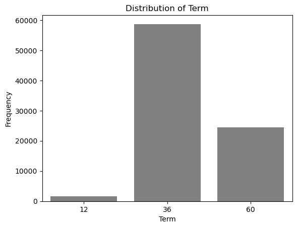

```python
# Visualise the distribution of Term
distribution_cat('Term', 0, loan)
```

#### Observation

> Most clients prefer medium-term loans of 36 months over short-term and long-term loans.

### LoanStatus

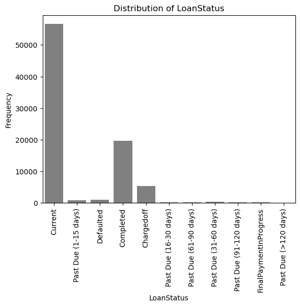

```python
# Visualise the distribution of 'LoanStatus'
distribution_cat('LoanStatus', 90,loan)
```

#### Observation

> From this distribution, it can be observed that the majority of loans are currently active (Current status), while a smaller number have been completed or charged off. A very small number of loans have defaulted or are past due for more than 120 days.

### ListingCategory

#### What are the reasons why People Borrow?

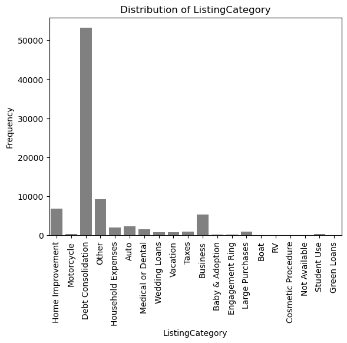

```python
# Visualise the distribution
distribution_cat('ListingCategory', 90, loan)
```

#### Observation

> Based on the above visual, the dorminant reason for borrowing is for debt consolidation purposes. The next most common category is "Other", which is not a very descriptive category.

> After that, we see a few reasons with a moderate number of borrowers, such as for Home Improvement and Business.

> The remaining categories have fewer loans associated with them, with some having only a handful of clients (such as Green Loans with 59 borrowers and RV with 52 borrowers).

> Overall, the distribution of Listing Category is heavily skewed towards debt consolidation, with a long tail of less frequently occurring rasons.

### ProsperRatingAlpha

```python
# Convert ProsperRating into ordered categorical types
rate_order = ['HR', 'E', 'D', 'C', 'B', 'A', 'AA']
ordered_var = pd.CategoricalDtype(categories=rate_order, ordered=True)
loan['ProsperRatingAlpha'] = loan['ProsperRatingAlpha'].astype(ordered_var)
```

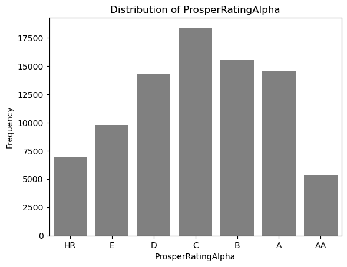

```python
# Visualise the distribution of Term
distribution_cat('ProsperRatingAlpha',0, loan)
```

#### Observation

> This column was first converted to ordinal data.

### IsBorrowerHomeowner

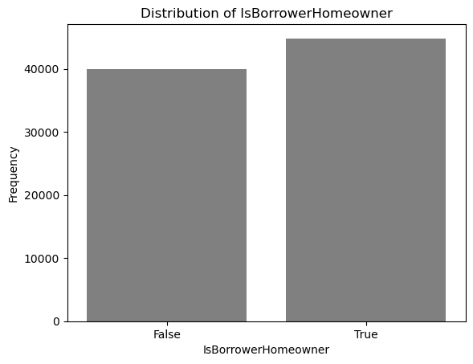

```python
# Visualise the Distribution using the Function
distribution_cat('IsBorrowerHomeowner', 0,loan)
```

#### Observation

> There is fairly no much difference in terms of the number of borrowers who own a house and those who do not.

### IncomeRange

```python
# Convert ProsperRating into ordered categorical types
income_order = ['$0', 'Not employed', '$1-24,999', '$25,000-49,999', '$50,000-74,999', '$75,000-99,999', '$100,000+']
ordered_income = pd.CategoricalDtype(categories=income_order, ordered=True)
loan['IncomeRange'] = loan['IncomeRange'].astype(ordered_income)
```

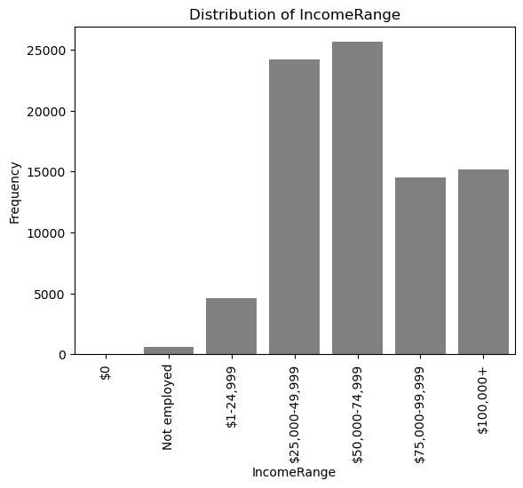

```python
# Visualise the Distribution using the Function
distribution_cat('IncomeRange', 90, loan)
```

#### Observation

> To obtain a clear pattern, the Income Range Category was ordered.

> A lot of Prosper Borrowers have income ranges above 25000 dollars with few borrowers earning below 25000. However, clients whose earnings are above 75000 tend to apply for loans less as compared to clients earning between 25000 and 74,000.

### IncomeVerifiable

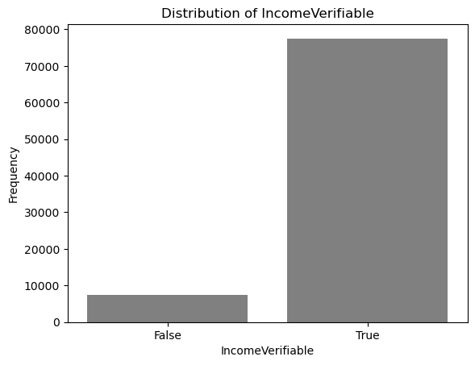

```python
# Visualise the Distribution using the Function
distribution_cat('IncomeVerifiable', 0, loan)
```

#### Observation

> A lot of clients have their incomes verified

### Recommendations

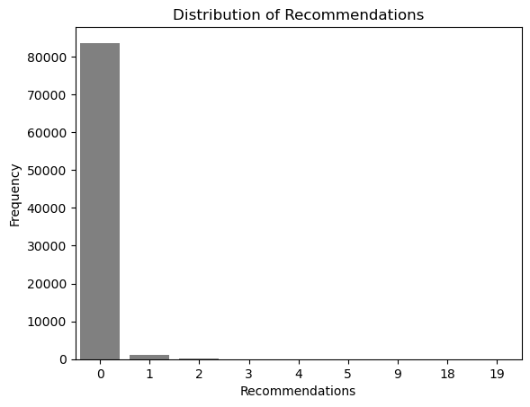

```python
# Visualise the Distribution using the Function
distribution_cat('Recommendations', 0, loan)
```

#### Observation

> As seen from the visual above,over 90% of borrowers do not have any recoomendations at time of the Listing. Just a handful have about 1 or 2 recommendations.

### EmploymentStatus

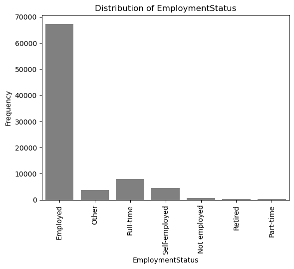

```python
# Visualise the Distribution using the Function
distribution_cat('EmploymentStatus', 90,loan)
```

#### Observation

> Majority of borrowers are employed. Fairly a large number of borrowers are in full-time as well. Majority of borrowers are employed. Fairly a large number of borrowers are in full-time as well. with an appreciable number being self-employed. There are also borrowers who fall under the category of "other" employment status.

## What is the Distribution of Numerical Variables

```python
def hist_plot(column_name, bins, df):
    """

    Returns Visual(Histogram) showing the distribution of the specified variable in the dataframe.
    Input: Takes a dataframe, a variable name, and a number(int).

    df: The dataframe
    column_name: The column's whose distribution you wish to visualise.
    bins: This specifies the number of bins of the Historgram.

    Output:
    Returns a visual showing a Histogram distribution.

    """
    plt.figure(figsize=[15,8])
    sb.histplot(df[column_name], bins=bins, color ='Grey')
    plt.xlabel(column_name)
    plt.ylabel('Count')
    plt.title(f'Distribution of {column_name}')
    plt.show()
```

#### What is the distribution of loan amounts requested by borrowers?

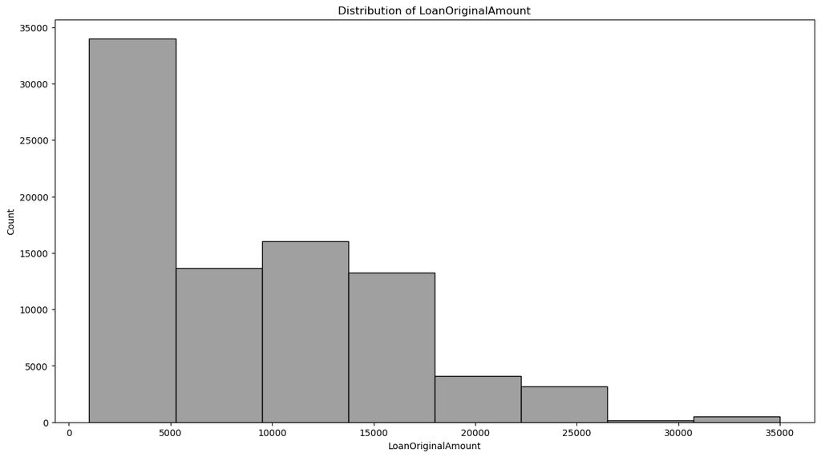

```python
# Visualise the Distribution using the Function
hist_plot('LoanOriginalAmount',8, loan)
```

#### Observation

> The distribution of LoanOriginalAmount is skewed towards the right, indicating that there are a large number of loan listings with lower LoanOriginalAmount values and a small number of listings with higher LoanOriginalAmount values.

### BorrowerAPR

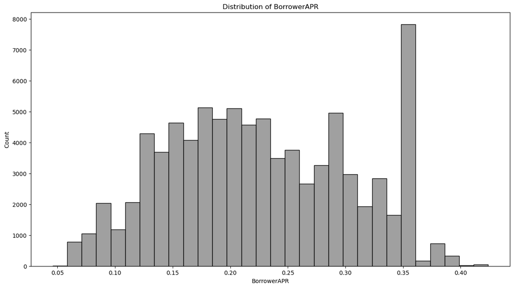

```python
# Visualise the Distribution using the Function
hist_plot('BorrowerAPR',30, loan)
```

#### Observation

> Borrower APR distribution assumes multimodal distribution, with a peak neighbourhoods of 0.35. However, only few listings have borrower APR greater than 0.4.

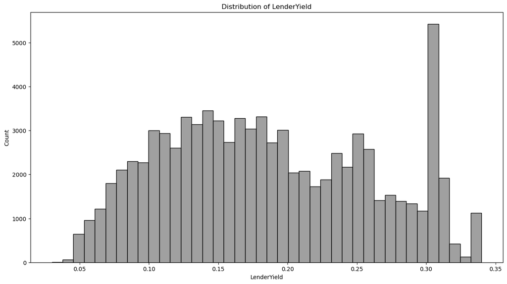

```python
# Visualise the Distribution using the Function
hist_plot('LenderYield',40, loan)
```

### EmploymentStatusDuration

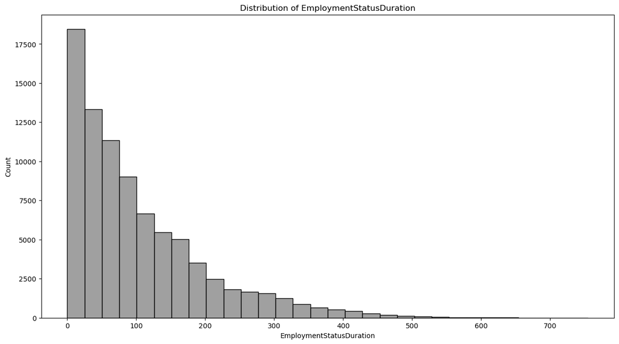

```python
# Visualise the Distribution using the Function
hist_plot('EmploymentStatusDuration',30, loan)
```

#### Observation

> Employment status duration is highly right skewed

### StatedMonthlyIncome

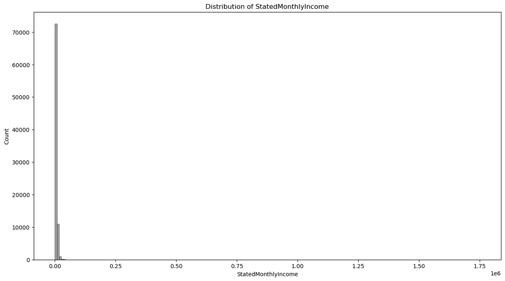

```python
# Visualise the Distribution using the Function
hist_plot('StatedMonthlyIncome',200, loan)
```

#### Observation

> Due to the inclusion of high-earning individuals in the dataset, the distribution of stated monthly income exhibits a significant right skew. The plot indicates that the majority of borrower incomes are below $250,000.

### BorrowerRate

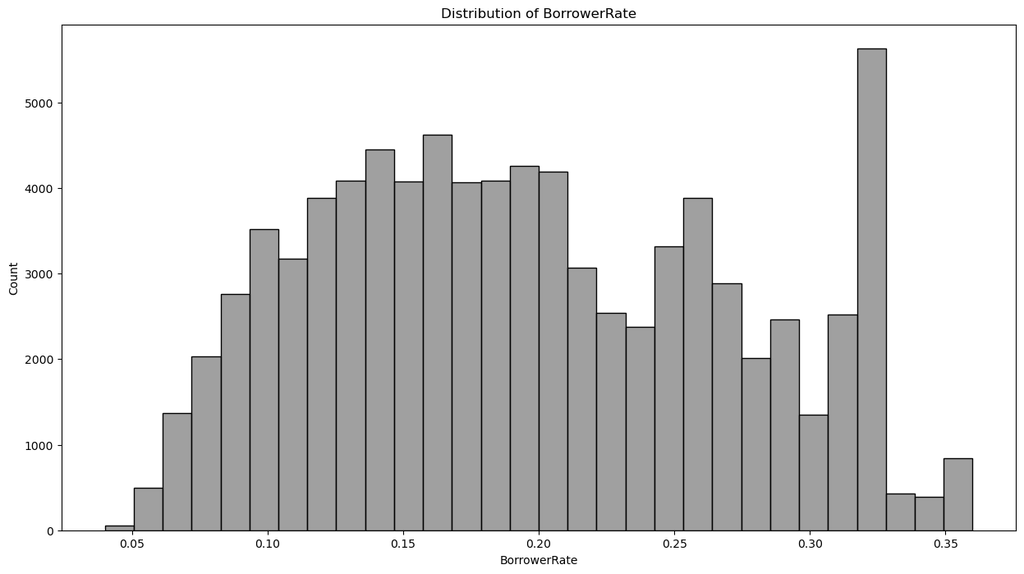

```python
# Visualise the Distribution using the Function
hist_plot('BorrowerRate',30, loan)
```

#### Observations

> Borrower Rate looks more multimodal with a sharp peak located between 0.3 and 0.35

### Discuss the distribution(s) of your variable(s) of interest. Were there any unusual points? Did you need to perform any transformations?

> Majority of the numerical features are skewed to the right.

### Of the features you investigated, were there any unusual distributions? Did you perform any operations on the data to tidy, adjust, or change the form of the data? If so, why did you do this?

> To obtain a clear pattern, the Income Range Category was converted to ordinal categorical data.

> Also, the Prosper Rating was also converted to ordinal categorical data.

## Bivariate Exploration

> In this section, the aim is to uncover intriguing associations that demonstrate the impact of a variable on another, specifically focusing on the target variables: Loan Original Amount and Prosper Rating.

### What is the correlation between all numerical variables?

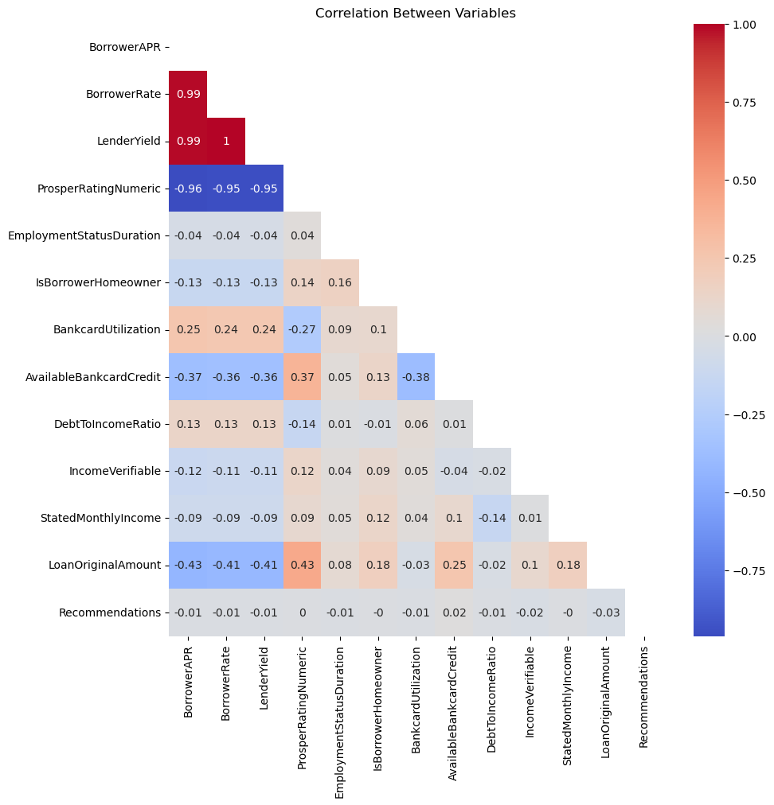

```python
# Create list of numerical variables of interest
num_variables =['BorrowerAPR',
 'BorrowerRate',
 'LenderYield',
 'ProsperRatingNumeric',
 'EmploymentStatus',
 'EmploymentStatusDuration',
 'IsBorrowerHomeowner',
 'BankcardUtilization',
 'AvailableBankcardCredit',
 'DebtToIncomeRatio',
 'IncomeVerifiable',
 'StatedMonthlyIncome',
 'LoanOriginalAmount',
 'Recommendations']

# Subset all numerical columns
loan_num = loan[num_variables]

# compute the correlation between variables
corr = loan_num.corr().round(2)

# hide upper diagonal of heatmap since it presents duplicate information
mask = np.triu(np.ones_like(corr,dtype=bool))

# Visualise the correlation between the numerical variables using a heatmap
plt.figure(figsize=(10,10))
sb.heatmap(corr,
            annot = True, mask = mask,
            cmap='coolwarm')
plt.title("Correlation Between Variables")
plt.show()
```

#### Observation

> BorrowerAPR has a strong positive correlation with Borrower Rate and Lender Yield.

> Prosper Rating has a strong negative correlation with Borrower APR, Borrower Rate and Lender Yield.

> The remaining variable pairs have no correlation with a few pairs like prosper rating and loan amount, loan amount and borrower APR being fairly moderately correlated.

> Various visuals will be generated below to further confirm this correlation.

### How does interest rate relate to Prosper rating?

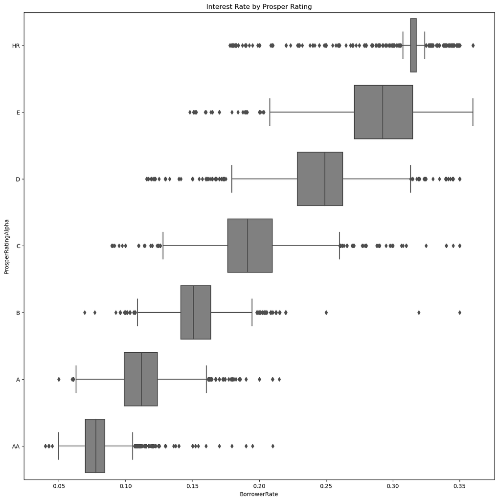

```python
plt.figure(figsize=(15,15))
sb.boxplot(data=loan, x= 'BorrowerRate', y='ProsperRatingAlpha', color='Grey')
plt.title("Interest Rate by Prosper Rating")
plt.show()
```

#### Observation

> It can be observed that Borrower rates increases with increasing risks (Prosper Rating). This further confirms the strong negative correlation between Prosper Rating and Borrower Rate.

### How does Borrower's Home ownage status affect Loan Amount and or Prosper Rating?

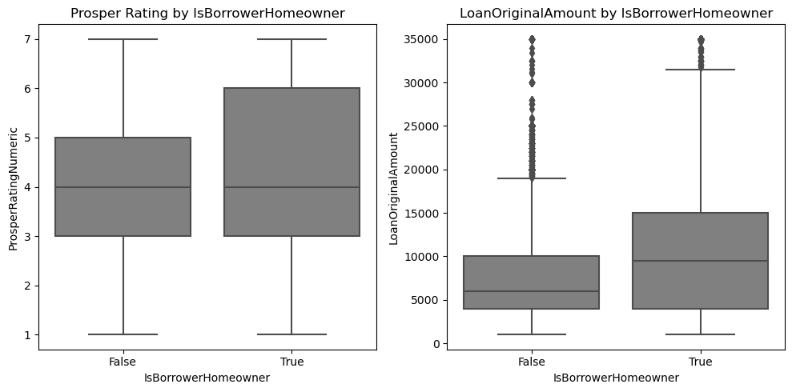

```python
# Create a figure with two subplots side by side
fig, axs = plt.subplots(1, 2, figsize=(10, 5))

# Create a boxplot for ProsperRatingNumeric by IsBorrowerHomeowner on the first subplot
sb.boxplot(data=loan, x='IsBorrowerHomeowner', y='ProsperRatingNumeric', color='Grey', ax=axs[0])

# Set the title for the first subplot
axs[0].set_title("Prosper Rating by IsBorrowerHomeowner")

# Create a boxplot for LoanOriginalAmount by IsBorrowerHomeowner on the second subplot
sb.boxplot(data=loan, x='IsBorrowerHomeowner', y='LoanOriginalAmount', color='Grey', ax=axs[1])

# Set the title for the second subplot
axs[1].set_title("LoanOriginalAmount by IsBorrowerHomeowner")

# Adjust the spacing between the subplots
plt.tight_layout()

# Display the plot
plt.show()
```

#### Observation

> It confirms the no correlation presented by the heat map above.

> Borrowers who owns homes tend to averagely get larger loans than those who do not own homes.

### How does Listing Category affect Prosper Rating?

### Is there any observable association between ProsperRating and EmploymentStatus?

### Is there relationship between Prosper Rating and Income Range?

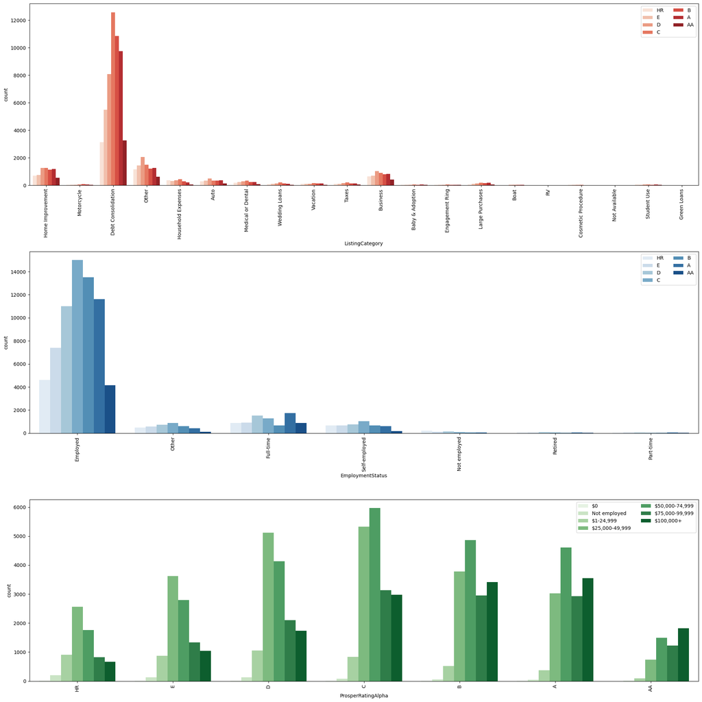

```python
plt.figure(figsize = [20, 20])

# subplot 1: How does Listing Category affect Prosper Rating?
plt.subplot(3, 1, 1)
sb.countplot(data = loan, x = 'ListingCategory', hue = 'ProsperRatingAlpha', palette = 'Reds')
plt.xticks(rotation =90)
plt.legend(ncol = 2)

# subplot 2: Is there any observable association between ProsperRating and EmploymentStatus?
plt.subplot(3, 1, 2)
sb.countplot(data = loan, x = 'EmploymentStatus', hue = 'ProsperRatingAlpha', palette = 'Blues')
plt.xticks(rotation =90)
plt.legend(ncol = 2)

# subplot 3: Is there relationship between Prosper Rating and Income Range?
plt.subplot(3, 1, 3)
sb.countplot(data = loan, x = 'ProsperRatingAlpha', hue = 'IncomeRange', palette = 'Greens')
plt.xticks(rotation =90)
plt.legend(loc = 1, ncol = 2)

plt.tight_layout()
plt.show()
```

### What is the relationship between Loan Amount and Income Range and Prosper Rating and Income Range?

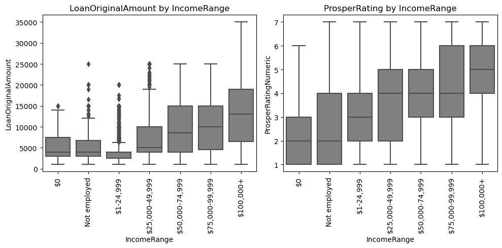

```python
# Create a figure with two subplots side-by-side
fig, axs = plt.subplots(1, 2, figsize=(10, 5))

# Create a boxplot of LoanOriginalAmount by IncomeRange and add it to the first subplot
sb.boxplot(data=loan, x='IncomeRange', y='LoanOriginalAmount', color='Grey', ax=axs[0])
# Set the title of the first subplot
axs[0].set_title("LoanOriginalAmount by IncomeRange")
# Rotate the x-axis labels to avoid overlap
axs[0].set_xticklabels(axs[0].get_xticklabels(), rotation=90)

# Create a boxplot of ProsperRatingNumeric by IncomeRange and add it to the second subplot
sb.boxplot(data=loan, x='IncomeRange', y='ProsperRatingNumeric', color='Grey', ax=axs[1])
# Set the title of the second subplot
axs[1].set_title("ProsperRating by IncomeRange")
# Rotate the x-axis labels to avoid overlap
axs[1].set_xticklabels(axs[1].get_xticklabels(), rotation=90)

# Adjust the layout of the subplots to prevent overlap
plt.tight_layout()
# Show the plot
plt.show()
```

#### Observation

> Borrowers with income less than 25000 usually go for loans less than USD 5000. However those whose income are are greater the 25000 go for much bigger loans.

> Prosper Rating Increases as Borrower's income increases.

### Talk about some of the relationships you observed in this part of the investigation. How did the feature(s) of interest vary with other features in the dataset?

> BorrowerAPR has a strong positive correlation with Borrower Rate and Lender Yield.

> Prosper Rating has a strong negative correlation with Borrower APR, Borrower Rate and Lender Yield.

> The remaining variable pairs have no correlation with a few pairs like prosper rating and loan amount, loan amount and borrower APR being fairly moderately correlated.

> Borrowers with income less than 25000 usually go for loans less than USD 5000. However those whose income are are greater the 25000 go for much bigger loans.

> Prosper Rating Increases as Borrower's income increases.

### Did you observe any interesting relationships between the other features (not the main feature(s) of interest)?

> No

## Multivariate Exploration

> This section focuses on validating the findings and checking the interactions between multiple variables.

### How do BorrowerAPR, LoanOriginalAmount, and ProsperRating interact with each other?

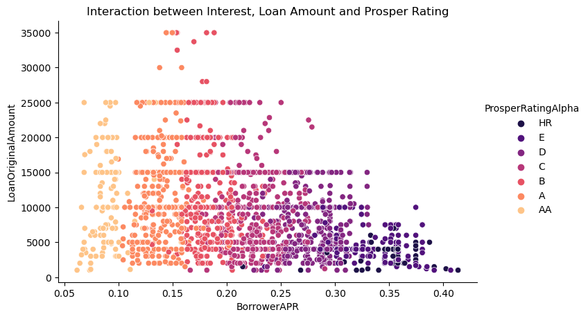

```python
sb.relplot(y='LoanOriginalAmount', x='BorrowerAPR', hue='ProsperRatingAlpha',
            data=loan.sample(n=2000, random_state=42), palette='magma', height=4.5, aspect=1.6)
plt.title('Interaction between Interest, Loan Amount and Prosper Rating')
```

#### Observation

> Based on the visual, borrowers who have lower prosper ratings tend to borrow smaller loan amounts with higher interest rates. Conversely, borrowers with higher prosper ratings are more likely to secure larger loan amounts with lower interest rates

### What is the interaction between Prosper Rating,loan Term, loan Amount and Monthly income?

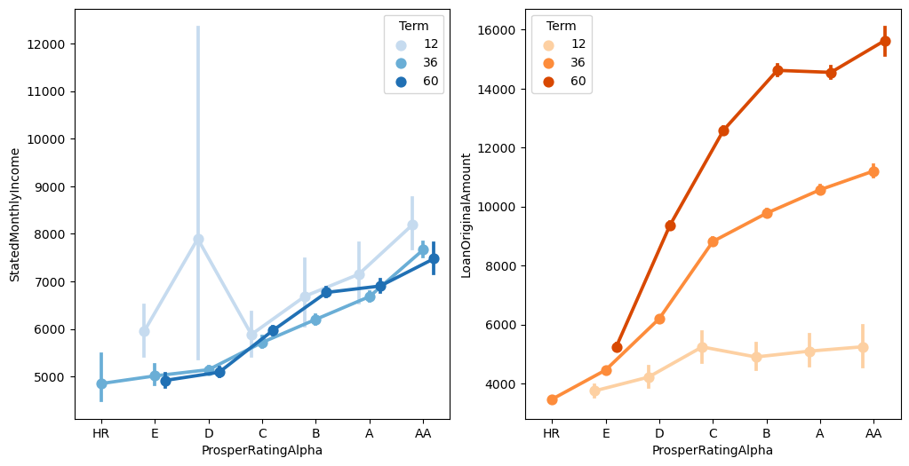

```python
fig, ax = plt.subplots(1, 2, figsize=[12,6])
for i, y_var in enumerate(['StatedMonthlyIncome', 'LoanOriginalAmount']):
    sb.pointplot(data=loan, x='ProsperRatingAlpha', y=y_var, hue='Term',
                 palette=['Blues', 'Oranges'][i], dodge=0.4, ax=ax[i])
```

#### Observation

> It appears that the relationship between term and rating is not influenced by the stated monthly income. The pattern of term remains consistent across different ratings.

> However, there is an interaction between term and rating when it comes to loan amount. As the Prosper rating improves, the loan amount increases for all three terms, with a larger increase in loan amount between terms.

### Talk about some of the relationships you observed in this part of the investigation. Were there features that strengthened each other in terms of looking at your feature(s) of interest?

> There is an interaction between term and rating when it comes to loan amount. As the Prosper rating improves, the loan amount increases for all three terms, with a larger increase in loan amount between terms

### Were there any interesting or surprising interactions between features?

> Based on the visual, borrowers who have lower prosper ratings tend to borrow smaller loan amounts with higher interest rates. Conversely, borrowers with higher prosper ratings are more likely to secure larger loan amounts with lower interest rates

```python
# Save final data as'loan.csv' to be loaded into another notebook
loan.to_csv('loan.csv', index = False)
```

## Conclusions

> The exploration of the dataset was aimed at finding factors that influence Loan Amount and Prosper Rating. To enable great insight, the exploration was based on the question-answer framework. Below are some of the questions

> What is the distribution of the numerical and categorical variables?

> What is the correlation between all numerical variables?

> How does interest rate relate to Prosper rating?

> How does Borrower's Home ownage status affect Loan Amount and or Prosper Rating?

> How does Listing Category affect Prosper Rating?

> Is there any observable association between ProsperRating and EmploymentStatus?

> Is there relationship between Prosper Rating and Income Range?

> What is the relationship between Loan Amount and Income Range and Prosper Rating and Income Range?

In conclusion, borrowers with lower Prosper ratings were more likely to borrow smaller amounts with higher interest rates. On the other hand, borrowers with higher Prosper ratings were more likely to obtain larger loans with lower interest rates. Loan term and rating also interacted, with loan amounts increasing as the Prosper rating improved, especially between different terms.

## Limitation

The exploration only considered a subset of variables, which is less than 40% of the total variables, and it is possible that there are other variables that could have a substantial impact on the target variables.

The research was centered on analyzing the Borrower's conduct and did not examine the behavior of the investors.

The analysis concentrated on identifying the correlations between different features, but we cannot establish a causal relationship between one feature and another since no statistical tests were conducted. Our study was entirely observational.